# Презентация по лабораторной работе 3

Иммитационное моделирование

Нджову Нелиа

1032239033@rudn.ru

Российский университет дружбы народов

## Цель работы

Цель этой лабораторной работы использовать агентную модель для моделирования daisyworld.

## Задание

1. Реализация на Agents.jl
2. Базовая визуализация
3. Анимация модели
4. Динамика числа маргариток

## Задание

5. Динамика модели
6. Базовая визуализация(параметры)
7. Динамика числа маргариток(параметы)
8. Динамика модели(параметры)

## Агентный подход

Агентный подход к имитационному моделированию (Agent-Based Modeling, ABM) — это метод исследования сложных систем, в котором поведение системы возникает из взаимодействия множества автономных сущностей, называемых агентами. Вместо того чтобы описывать систему глобальными уравнениями, мы моделируем каждую индивидуальную единицу и правила её поведения, а затем наблюдаем, какие коллективные паттерны появляются снизу вверх. Этот подход особенно полезен, когда поведение системы трудно предсказать из-за нелинейностей, гетерогенности участников или адаптивных стратегий.

## Агентный подход

Любая агентная модель включает три основных элемента:

1. Агенты — это активные сущности. Они обладают свойствами, правилами поведения, целями и способностью к обучению или одаптации
2. Среда — это пространство, в котором существуют агенты. Она может быть дискретной, непрерывной, сетевой и абстрактной. Среда также может иметь свои свойства (температура, ресурсы) и динамику (диффузия, обновление).

## Агентный подход

3. Взаимодействия — правила, определяющие, как агенты влияют друг на друга и на среду. Они могут быть локальными, глобальными и через среду.

Основные принципы агентного моделирования включает эмерджентность, автономия, генерогенность и локальность

Преимущества агентного подхода включает гибкость, учёт индивидуальных реализаций, адаптивность, наглядность и исследование

Этапы построения агентной модели: концептуализация, спецификация, реализация, верификация, валидация, анализ и интерпретация

## Модель Daisyworld

**Модель Daisyworld**, предложенная Джеймсом Лавлоком и Эндрю Уотсоном (1983), иллюстрирует гипотезу Геи — способность жизни регулировать планетарные условия.

**Основные элементы модели:**

**1. Агенты (маргаритки)** - Два типа: **чёрные** (низкое альбедо 0.25) и **белые** (высокое альбедо 0.75) - Свойства: тип, возраст, альбедо, позиция на сетке - Правила: стареют, умирают при достижении max_age, размножаются в пустые соседние клетки

## Модель Daisyworld

**2. Среда (планета)** - Дискретная сетка 30×30 клеток - Свойства: температура каждой клетки, солнечная светимость - Динамика: диффузия тепла между соседними клетками

**3. Взаимодействия** - Маргаритки **влияют на среду**: чёрные поглощают тепло (нагревают), белые отражают тепло (охлаждают) - Среда **влияет на агентов**: размножение возможно только при оптимальной температуре (~22.5°C)

## Модель Daisyworld

**Механизм саморегуляции:**

- **Слишком холодно** Чёрные маргаритки получают преимущество → распространяются → поглощают больше тепла → **планета нагревается**
- **Слишком жарко** Белые маргаритки получают преимущество → распространяются → отражают больше тепла → **планета охлаждается**

## Модель Daisyworld

**Ключевые параметры:**

| Параметр | Значение |
| --- | --- |
| Максимальный возраст | 25-40 шагов |
| Альбедо чёрных | 0.25 |
| Альбедо белых | 0.75 |
| Альбедо почвы | 0.4 |
| Оптимальная температура | 22.5°C |

## Модель Daisyworld

**Эмерджентное поведение:**

Несмотря на простые локальные правила, глобально система демонстрирует **поддержание стабильной температуры** в широком диапазоне солнечной активности — яркий пример саморегуляции без централизованного управления.

## Выполнение лабораторной работы

Я создала файл src/daisyworld.jl и скопировала скрипт код, который мне дали и запускала его. Этот скрипт код содержит ключевые функции например, функции обновления температуры, функция рассеивания тепла, функция воспроизведения ромашки, функция шага модели, функция солнечной активности и т.д.(рис. 1)

## Выполнение лабораторной работы

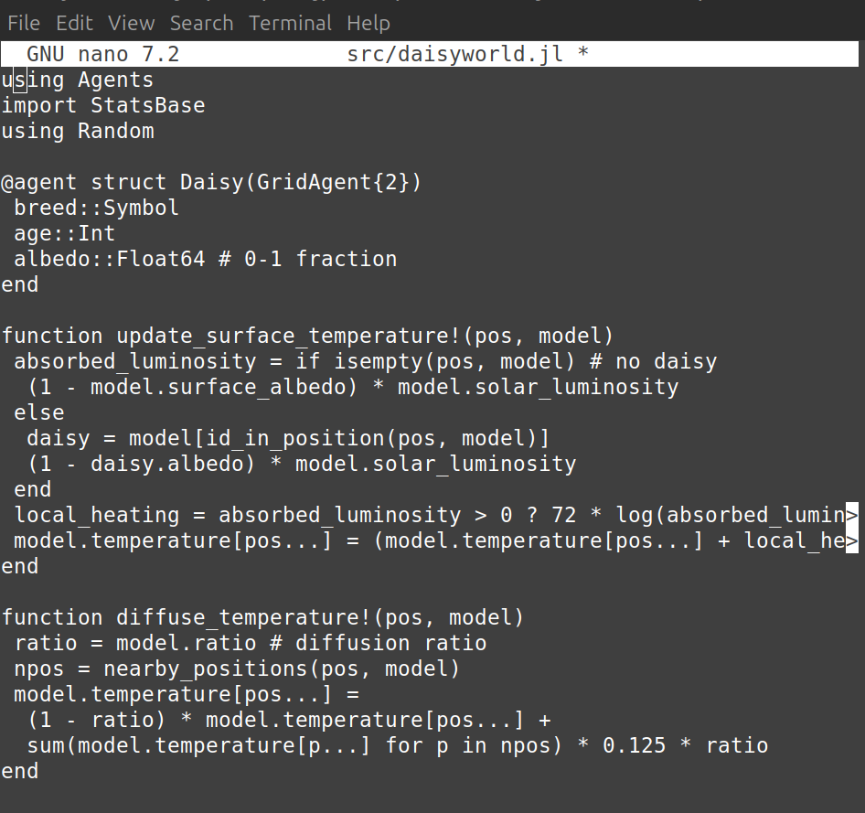

Рисунок 1: Ключевые функции модель Daisyworld